# Gulf of Mexico well permits: a public US data file (Deckhand newsletter, issue 2)

**Review copy, revision 12 (removed at publication)**

Checked and kept: the rig-type charts (Figures 2 and 3) keep their colours from revisions 9 to 11; navy (jack-up) and teal (drillship) are also two of the water-depth colours, but those charts never show water depth and their legends name every colour.

The Deckhand newsletter · Issue 2 · Public data

# Gulf of Mexico well permits: a public US data file

The Deckhand Chronicles is AceEngineer's newsletter. We help build AI into everyday engineering work.

[figure not shown]

Objective

Show where and how new Gulf wells are drilled, by rig type and water depth, from free public files.

Starting point

The US Bureau of Safety and Environmental Enforcement (BSEE) publishes its well permit and borehole records for federal waters as free raw data files.

What we did

Counted new-well permits since 2005 by rig type and water depth, mapped new wells year by year, and set their rolling averages beside the oil price.

What we found

New wells moved to deep water: 68.8 % were in less than 100 m in 2005 to 2009, 13.4 % in 2021 to 2025. After the oil price fell in 2015, shallow-water wells fell the most.

What you can do

Rerun the counts on the latest files and add your own questions, with the reusable prompts linked in Appendix A.

Sources: BSEE raw data files; EIA WTI spot price (section 1, Figure 1). Deckhand · AceEngineer

## What we did

Planning work over the life of a well starts from what was done before. The US offshore safety regulator publishes every application for a permit to drill in federal waters as a free data file. This first article of our series on the life of Gulf of America wells counts new-well permits since 2005, by rig type and water depth.

## Why it matters

- See where and how new wells are now drilled, and how the count moved with the oil price.
- Anyone can rerun the counts on the latest file and add their own questions.
- The counting rules and reusable prompts to rerun the counts are in our public repository.

Prompt: count new-well permits by year, rig type and water depth from the public permit file: [worldenergydata on GitHub](https://github.com/vamseeachanta/worldenergydata/tree/8c18f080938d4efea28dad6f696b125aacd028d8/examples/bsee/issue2_public_data_r12/prompts).

## What is inside

It holds a map of new wells by water depth, year by year, with their rolling averages beside the oil price, and the permits by rig type and depth band. Links to the reusable prompts and the counting rules are in Appendices A and B.

## 1 Public permit data

Public data shows how new-well permits in US federal waters of the Gulf of America (formerly the Gulf of Mexico) have changed since 2005. The counts come from the Application for Permit to Drill (APD) raw data of the US Bureau of Safety and Environmental Enforcement (BSEE). The map uses its borehole raw data; the oil price is the US Energy Information Administration (EIA) WTI spot price. The public data set is two BSEE raw data files (permits to drill, boreholes) and the EIA WTI spot price.

Some of the observations are as follows:

- Of the 1,584 new wells started from 2005 to 2009, 68.8 % were in less than 100 m of water and 23.3 % in 500 m or more; of the 246 started from 2021 to 2025, 13.4 % and 82.5 % (Figure 1a).
- When the WTI oil price fell from USD 93.26 a barrel in 2014 to USD 48.69 in 2015 (annual means), the three-year average of new wells in less than 100 m of water fell from about 62 a year (2012 to 2014) to about 12 (2015 to 2017); in 500 m or more it fell from about 76 to about 59 (Figure 1b).
- Each year now has far fewer permits than in the mid-2000s (Figure 2).
- Most permits once named a jack-up rig; since 2015, most name a drillship (Figure 2).
- Permits in less than 100 m fell the most. Those in 500 m or more changed far less; since 2015, they are most permits (Figure 4).

a. Where new wells started, by five-year window

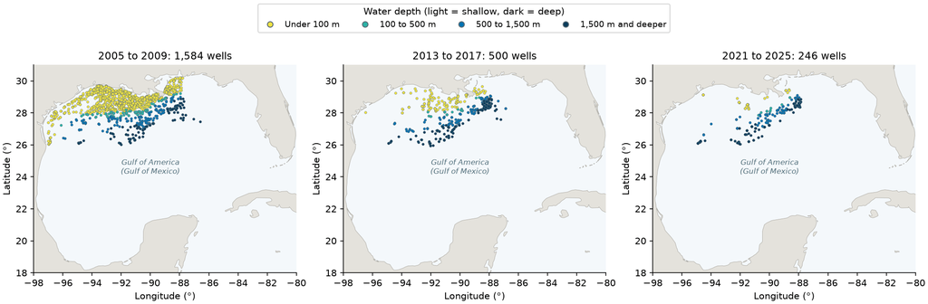

b. New wells each year, with rolling averages and the oil price

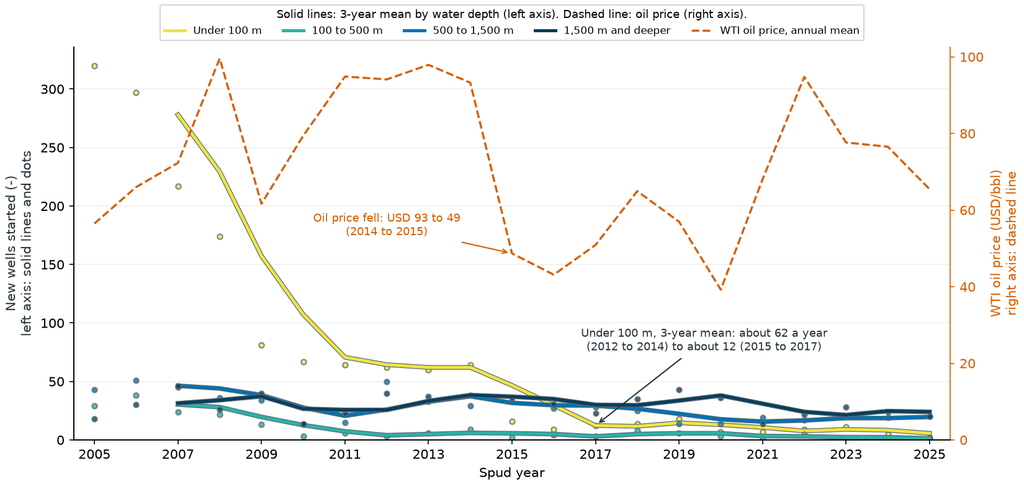

1. Each dot on the map is the surface location of an original borehole in the BSEE Gulf of Mexico region, spudded in the window shown; cancelled boreholes are left out. A window counts each well once; consecutive windows share four years.

2. Counts: 2005 to 2009: 1,584 wells (under 100 m: 1,089; 100 to 500 m: 126; 500 to 1,500 m: 209; 1,500 m and deeper: 160); 2021 to 2025: 246 wells (under 100 m: 33; 100 to 500 m: 10; 500 to 1,500 m: 95; 1,500 m and deeper: 108). Wells without coordinates in the map area: 0. Every window: map-windows.csv.

3. Panel b: dots are the wells started each year; lines are the three-year rolling average (the year and the two before it), from 2007. The dashed line is the annual mean of the monthly Cushing WTI spot price (right axis, in the oil-price colour); the labelled points are the readings of section 1. The price is shown beside the counts; no cause is fitted. Section 1 reads these three-year averages, new wells a year: under 100 m, 62.0 (2012 to 2014) and 12.3 (2015 to 2017); 500 m or more, 75.7 and 59.3.

4. Sources: BSEE borehole raw data (BoreholeRawData.zip), file of 12 November 2026, retrieved 13 November 2026; WTI spot price, US Energy Information Administration, as the repository snapshot wti-monthly.csv ([provenance](https://github.com/vamseeachanta/worldenergydata/blob/37e36be7c19d7e121d2d1208aff61ca9e6b1bb59/data/wti-monthly.PROVENANCE.md)); land outline from Natural Earth 1:50m land, version 5.1.2, public domain (ne_50m_land.geojson), retrieved 13 November 2026.

5. Data: map-wells-by-year.csv, new-wells-trend.csv and wti-annual.csv.

Figure 1 - Where new wells started, by water depth

The [raw data page](https://www.data.bsee.gov/Main/RawData.aspx) of the BSEE Data Center lists the files used here, and files on platform structures, pipelines, production and offshore statistics by water depth.

## 2 Well permits by rig type and water depth

The permit file holds each application for a permit to drill in US federal waters. Each record gives:

- The permit type.
- The requested spud date: the date drilling is to start.
- The water depth.
- The rig name and rig type.

The counting rules are:

- Count each well once, at its first New Well permit in the Gulf of Mexico region.
- Use the requested spud year and the rig type named on that permit.

From 2005 to 2026, 2,895 wells are counted this way. The rule leaves out each well's later permits, and the 10 wells whose first New Well permit gives no requested spud date. The year 2026 runs only to the file of 2 November 2026.

### 2.1 Rig type

The counting script names six rig types:

- Jack-up.
- Drillship.
- Semisubmersible.
- DP semisubmersible: dynamically positioned, held on station by its thrusters.
- Platform rig.
- Submersible.

Barge, barge rig and well intervention vessel (19 permits) are grouped as other. Figure 2 shows the new-well permits each year by rig type. Figure 3 shows the shares in 2005, 2015 and 2025, one full year per decade.

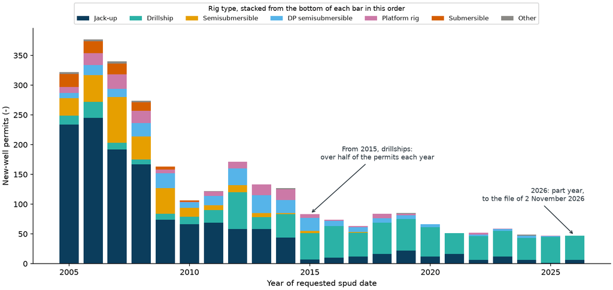

1. Gulf of Mexico region, 2005 to 2026, by year of requested spud date; one permit per well. 2026 is a part year, to the file of 2 November 2026.

2. Source: BSEE Application for Permit to Drill raw data (APDRawData.zip), file of 2 November 2026, retrieved 3 November 2026.

3. Data: fig-p1-new-well-permits-by-rig-type.csv.

Figure 2 - New-well permits by rig type

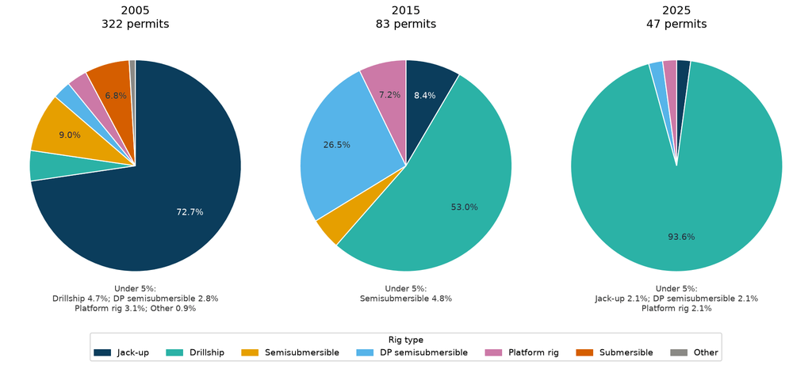

1. Permits each year: 322 in 2005, 83 in 2015, 47 in 2025.

2. A rig type with no permits in a year is left out of that year's pie.

3. Counts, source and file date as Figure 2. Data: pies-rig.csv.

Figure 3 - Rig-type shares in 2005, 2015 and 2025

### 2.2 Water depth

Every permit counted records a water depth. The file gives it in feet; this page gives it in metres (1 ft = 0.3048 m exactly, [NIST SP 811, Appendix B.8](https://www.nist.gov/pml/special-publication-811/nist-guide-si-appendix-b-conversion-factors/nist-guide-si-appendix-b8)). Figure 4 shows the new-well permits each year in four water-depth bands: under 100 m, 100 to 500 m, 500 to 1,500 m, and 1,500 m and deeper. A depth on a band edge is counted in the deeper band. Figure 5 shows the shares in the same three years.

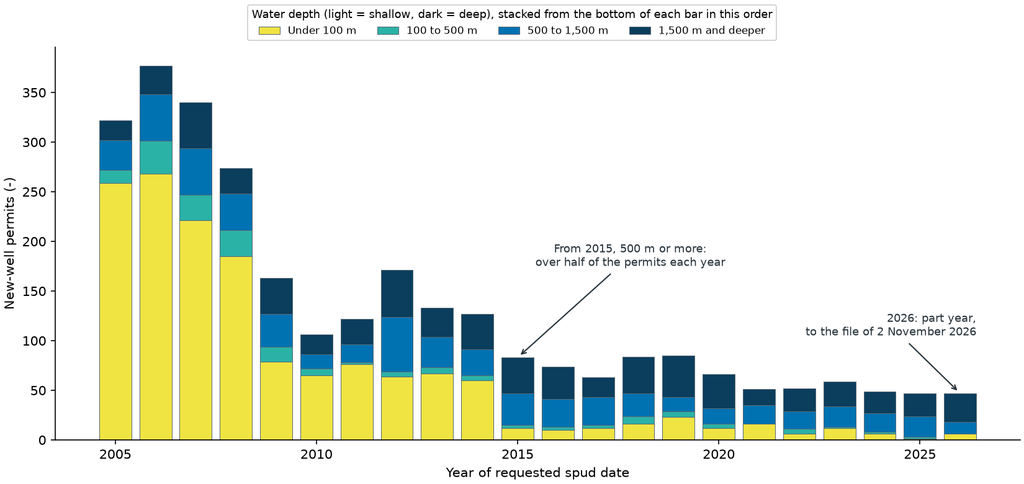

1. Gulf of Mexico region, 2005 to 2026, by year of requested spud date; one permit per well. 2026 is a part year, to the file of 2 November 2026.

2. Source: BSEE Application for Permit to Drill raw data (APDRawData.zip), file of 2 November 2026, retrieved 3 November 2026.

3. Colours: lighter to darker as the water deepens. The same four colours mark the water-depth bands in every figure of this article.

4. Data: new-well-permits-by-water-depth.csv.

Figure 4 - New-well permits by water depth

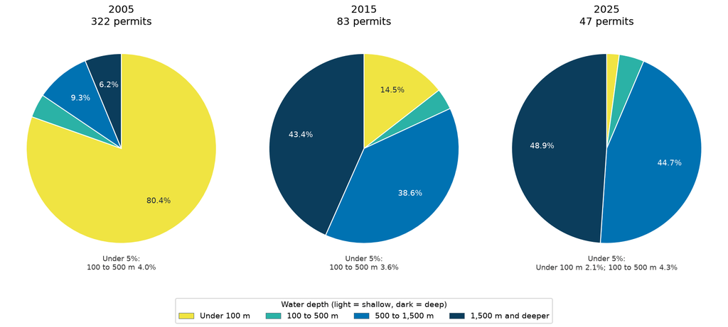

1. Permits each year: 322 in 2005, 83 in 2015, 47 in 2025.

2. A band with no permits in a year is left out of that year's pie.

3. Counts, source and file date as Figure 4. Data: pies-depth.csv.

Figure 5 - Water-depth shares in 2005, 2015 and 2025

### 2.3 Rig type and water depth

Table 1 gives the permits of each rig type in the same four bands, with each rig type's median water depth.

| Rig type | New-well permits, 2005 to 2026 (-) | Under 100 m (-) | 100 to 500 m (-) | 500 to 1,500 m (-) | 1,500 m and deeper (-) | Median water depth (m) |
| --- | --- | --- | --- | --- | --- | --- |
| Jack-up | 1,333 | 1,316 | 17 | 0 | 0 | 31 |
| Drillship | 758 | 0 | 5 | 323 | 430 | 1,581 |
| Semisubmersible | 282 | 0 | 51 | 151 | 80 | 985 |
| DP semisubmersible | 260 | 0 | 9 | 108 | 143 | 1,604 |
| Platform rig | 162 | 62 | 93 | 7 | 0 | 119 |
| Submersible | 81 | 81 | 0 | 0 | 0 | 12 |
| Other | 19 | 17 | 0 | 0 | 2 | 4 |
| All | 2,895 | 1,476 | 175 | 589 | 655 |  |

1. Gulf of Mexico region, 2005 to 2026; one permit per well.
2. Source: BSEE Application for Permit to Drill raw data (APDRawData.zip), file of 2 November 2026, retrieved 3 November 2026.
3. Data: table1.csv.

Table 1 - New-well permits by rig type and water depth

The days at each stage of a well's life, from drilling to abandonment, move to the plugging-and-abandonment article of this series.

## 3 Outlook and open points

### 3.1 Our hypotheses

Our hypothesis: with few new-well permits now naming a jack-up (Figure 2), jack-up work in US federal Gulf of Mexico waters will turn further from new wells to plugging and abandonment.

Our hypothesis: with deep-water permits falling far less than shallow-water permits (Figure 4), new-well engineering in these waters will centre further on deep-water drilling, risers and subsea equipment.

### 3.2 Open points

- Each count takes the rig type named in a well's first permit. How often a different type of rig drilled the well is open.
- Figure 1b sets the oil price beside the well counts only. How much of each change follows the price, and how much follows other events such as changes in regulation, is open.

### 3.3 Try it out

To try it out or adapt the analysis, see reusable prompt.

AceEngineer carries out fixed-scope engineering projects, and helps engineering firms build AI into everyday engineering work, including analysis of public offshore data such as this.

If you have run your own analysis, see a way to improve this one, or have an idea for a future issue, write to [the maintainers](https://www.aceengineer.com/). We read every reply and credit the ideas we use and provide results we obtained.

Approval: awaiting maintainer review of revision 12

#GulfOfAmerica #GulfOfMexico #OffshoreDrilling #Deepwater #PlugAndAbandonment #PublicData #BSEE #WellEngineering #DeckhandChronicles

## Appendix A Reusable prompts

- Rerun these counts and the map on the latest public BSEE files with your own AI assistant.
- Adapt them to another region, other years or other water-depth bands, and check your result against the published values.

Prompts, files and check values: [worldenergydata on GitHub, issue2_public_data_r12/prompts](https://github.com/vamseeachanta/worldenergydata/tree/8c18f080938d4efea28dad6f696b125aacd028d8/examples/bsee/issue2_public_data_r12/prompts).

## Appendix B Counting rules and record counts

- How each well is counted once, how water depth is banded, and what is left out.
- The record counts behind every number, so a rerun can be checked line by line.

Full rules and counts: [worldenergydata on GitHub, counting-rules.md](https://github.com/vamseeachanta/worldenergydata/blob/8c18f080938d4efea28dad6f696b125aacd028d8/examples/bsee/issue2_public_data_r12/counting-rules.md).

Questions: [Contact the maintainers](https://www.aceengineer.com/)

Deckhand: Make Engineering Enjoyable Again